# Generalized Linear Models with the rstanarm R Package

April 20, 2020

## Important Maximimum Entropy Distributions

- If \(\Theta\) is some convex set, the maximum entropy distribution is the uniform distribution over \(\Theta\). For example, if \(\Theta = \left[0,1\right]\), it is the standard uniform distribution with PDF \(f\left(\left.\theta\right|a=0,b=1\right) = 1\)
- If \(\Theta = \mathbb{R}\), the maximum entropy distribution given an expectation and variance is the normal distribution. This extends to bivariate and multivariate distributions if you have given covariances.
- If \(\Theta = \mathbb{R}_+\), then the maximum entropy distribution for a given expectation is the exponential distribution with expectation \(\mu = \frac{1}{\lambda}\). You can utilize the fact that the median is \(F^{-1}\left(0.5\right) = \mu \ln 2\) to go from the median to \(\mu\).
- The binomial and Poisson distributions are maximum entropy distributions given \(\mu\) for their respective \(\Omega\)
- Additional examples (often with weird constraints) are given at the bottom of https://en.wikipedia.org/wiki/Maximum_entropy_probability_distribution

## Do This Once on Each Computer You Use

```r
cat('options(contrasts = c(unordered = "contr.treatment", ordered = "contr.treatment"))',
    file = "~/.Rprofile", sep = "\n", append = TRUE)
```

- Without this, you will get a weird rotation of the coefficients on dummy variables derived from ordered factors
- `"contr.sum"` is another reasonable (but rare) choice

## Prior Predictive Distribution for Roach Study

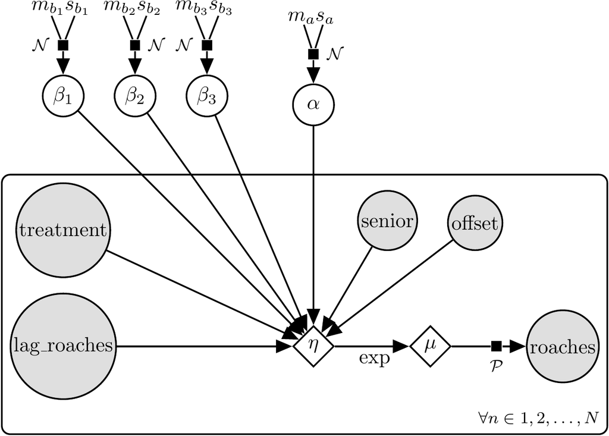

Roach Model

## Prior Predictive Distribution in Symbols

\[ \alpha \thicksim \mathcal{N}\left(m_\alpha, s_\alpha\right) \\ \beta_1 \thicksim \mathcal{N}\left(m_{\beta_1}, s_{\beta_1}\right) \\ \beta_2 \thicksim \mathcal{N}\left(m_{\beta_2}, s_{\beta_2}\right) \\ \beta_3 \thicksim \mathcal{N}\left(m_{\beta_3}, s_{\beta_3}\right) \\ \forall n: \eta_n = \alpha + OFFSET_n + \beta_1 \times \log LAG_n + \beta_2 \times SENIOR_n + \beta_3 \times T_n \\ \forall n: \mu_n = e^{\eta_n} \\ \forall n: Y_n \thicksim \mathcal{Poisson}\left(\mu_n\right) \]

## Breakout Rooms

Draw \(S = 1000\) times (using `replicate`) from a prior predictive distribution

```r
roaches <- roaches[roaches$roach1 > 0, ]; str(roaches)
```

```
## 'data.frame':    202 obs. of  5 variables:
##  $ y        : int  153 127 7 7 0 73 24 2 2 0 ...
##  $ roach1   : num  308 331.25 1.67 3 2 ...
##  $ treatment: int  1 1 1 1 1 1 1 0 0 0 ...
##  $ senior   : int  0 0 0 0 0 0 0 0 0 0 ...
##  $ exposure2: num  0.8 0.6 1 1 1.14 ...
```

- The average number of pre-treatment roaches (`roaches$roach1`) in a building was about \(42\) with a standard deviation of \(75\)
- Use `log(roach1)` as the predictor
- The offset is `log(roaches$exposure2)`
- Remember to center the predictors, including the offset, when predicting

## Posterior Distribution

```r
post <- stan_glm(y ~ senior + log(roach1) + treatment, data = roaches,
                 family = poisson, offset = log(exposure2), QR = TRUE,
                 prior_intercept = normal(location = log(42), scale = 4, autoscale = FALSE),
                 prior = normal(location = 0, scale = c(5, 5, 1), autoscale = FALSE))
```

```r
print(post, digits = 2)
```

```
...
##             Median MAD_SD
## (Intercept)  1.57   0.05
## senior      -0.46   0.04
## log(roach1)  0.62   0.01
## treatment   -0.49   0.03
##
## Sample avg. posterior predictive distribution of y:
##          Median MAD_SD
## mean_PPD 31.54   0.55
##
## ------
## * For help interpreting the printed output see ?print.stanreg
## * For info on the priors used see ?prior_summary.stanreg
...
```

## Estimating Treatment Effects

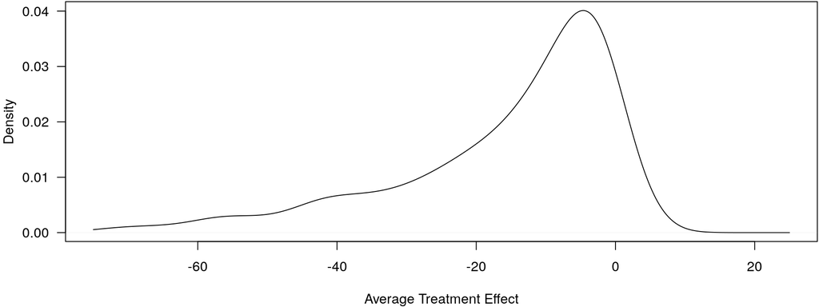

```r
df <- roaches; df$treatment <- 0
Y_0 <- posterior_linpred(post, newdata = df, offset = log(df$exposure2), transform = TRUE)
df$treatment <- 1
Y_1 <- posterior_linpred(post, newdata = df, offset = log(df$exposure2), transform = TRUE)
plot(density(colMeans(Y_1 - Y_0), from = -75, to = 25), xlab = "Average Treatment Effect", main = "")
```

## Why NUTS Is Better than Other MCMC Samplers

```r
round(bayesplot::neff_ratio(post), digits = 2)
```

```
## (Intercept)      senior log(roach1)   treatment
##        0.62        0.84        0.67        0.68
```

## Divergent Transitions

- NUTS only uses first derivatives
- First order approximations to Hamiltonian physiscs are fine for if either the second derivatives are constant or the discrete step size is sufficiently small
- When the second derviatives are very not constant across \(\Theta\), Stan can (easily) mis-tune to a step size that is not sufficiently small and \(\theta_k\) gets pushed to \(\pm \infty\)
- When this happens there will be a warning message, suggesting to increase `adapt_delta`
- When `adapt_delta` is closer to 1, Stan will tend to take smaller steps
- Unfortunately, even as `adapt_delta` \(\lim 1\), there may be no sufficiently small step size and you need to try to reparameterize your model

## Exceeding Maximum Treedepth

- When the step size is small, NUTS needs many (small) steps to cross the “typical” subset of \(\Theta\) and hit the U-turn point
- Sometimes, NUTS has not U-turned when it reaches its limit of 10 steps (by default)
- When this happens there will be a warning message, suggesting to increase `max_treedepth`
- There is always a sufficiently high value of `max_treedepth` to allow NUTS to reach the U-turn point, but increasing `max_treedepth` by 1 approximately doubles the wall time to obtain \(S\) draws

## Runtime Exceptions

- Sometimes you will get a “informational” (not error, not warning) message saying that some parameter that should be positive is zero or some parameter that should be finite is infinite
- This means that a 64bit computer could not represent the number accurately
- If it only happens a few times and only during the warmup phase, do not worry
- Otherwise, you might try to use functions that are more numerically stable, which is discussed throughout the Stan User Manual

## Initial Values

- Sometimes a Markov Chain will not get started because the log-kernel evaluates to \(-\infty\) or `NaN` at the initial values (which are randomly generated)
- You can provide you own initial values
- But it is usually easier to specify `init_r` to be some value between 0 and 2 (the default) which governs the range at which the initial values are drawn from on the unconstrained scale

## Tail / Bulk ESS

- Sometimes you will get a message about the tail or bulk ESS being low
- Call `monitor` on an object produced by Stan to see the estimates
- I do not worry too much about it if ONLY the `lp__` margin is too low
- Otherwise, you can increase the number of iterations and / or chains
- But it does suggest that there is something in the parameterization of your model that would make it difficult for Stan to sample from the implied posterior distribution

## ShinyStan

- ShinyStan can be launched on an object produced by rstanarm via

```r
launch_shinystan(post)
```

- A webapp will open in your default web browser that helps you visualize the posterior distribution and diagnose problems

## Sensitivity to Individual Observations

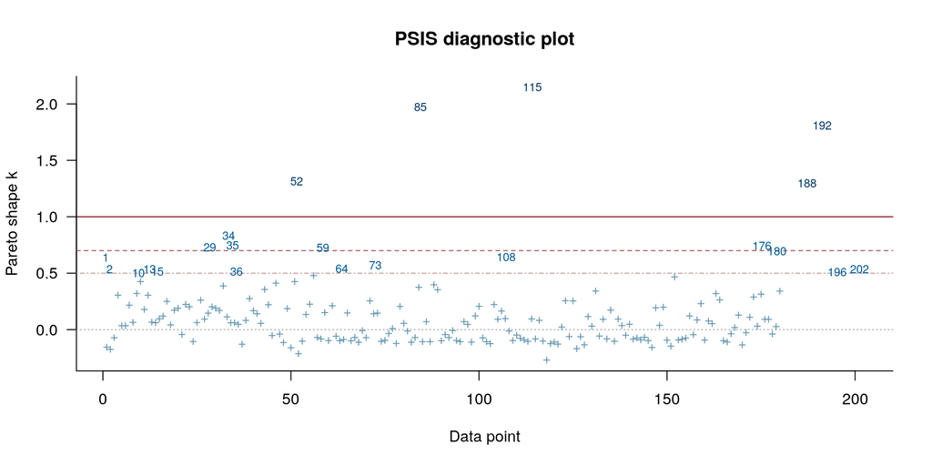

```r
plot(loo(post), label_points = TRUE)
```

## Numerical Assessment of Calibration

```r
PPD <- posterior_predict(post); dim(PPD)
```

```
## [1] 4000  202
```

```r
lower <- apply(PPD, MARGIN = 2, FUN = quantile, probs = 0.25)
upper <- apply(PPD, MARGIN = 2, FUN = quantile, probs = 0.75)
mean(roaches$y > lower & roaches$y < upper) # bad fit
```

```
## [1] 0.04950495
```

- Overal, the model is fitting the data poorly
- You will often overfit when you lazily use all predictors that are available in the dataset

## Leave-One-Out Based Intervals

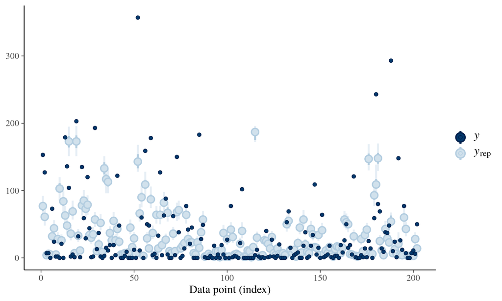

```r
library(bayesplot)
pp_check(post, plotfun = "loo_intervals")
```

## Leave-One-Out Probability Integral Transform

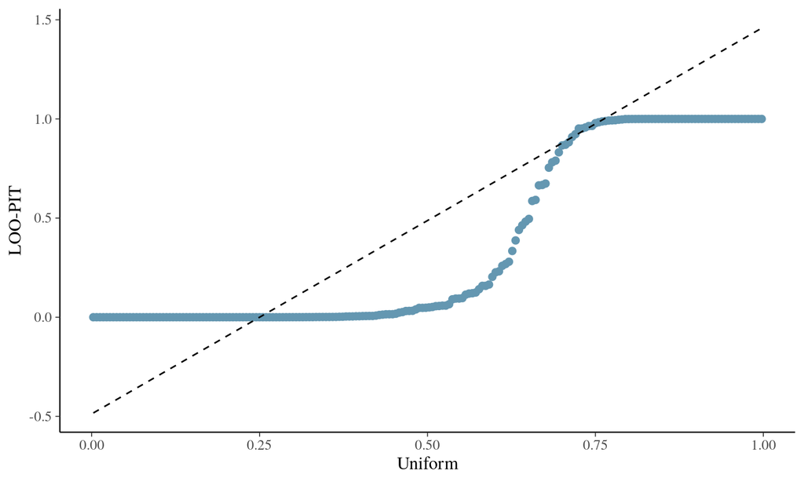

```r
pp_check(post, plotfun = "loo_pit_qq")
```

## Scatterplots

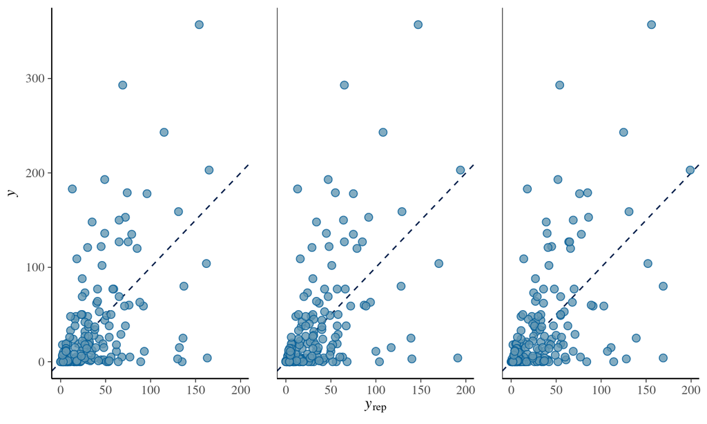

```r
pp_check(post, plotfun = "scatter")
```

## Frequency Polygons

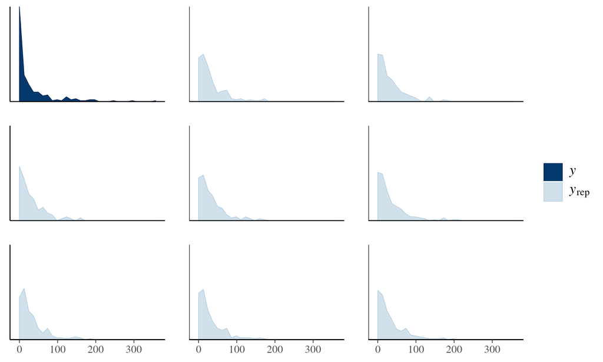

```r
pp_check(post, plotfun = "freqpoly")
```

## Frequency Polygons with Grouping

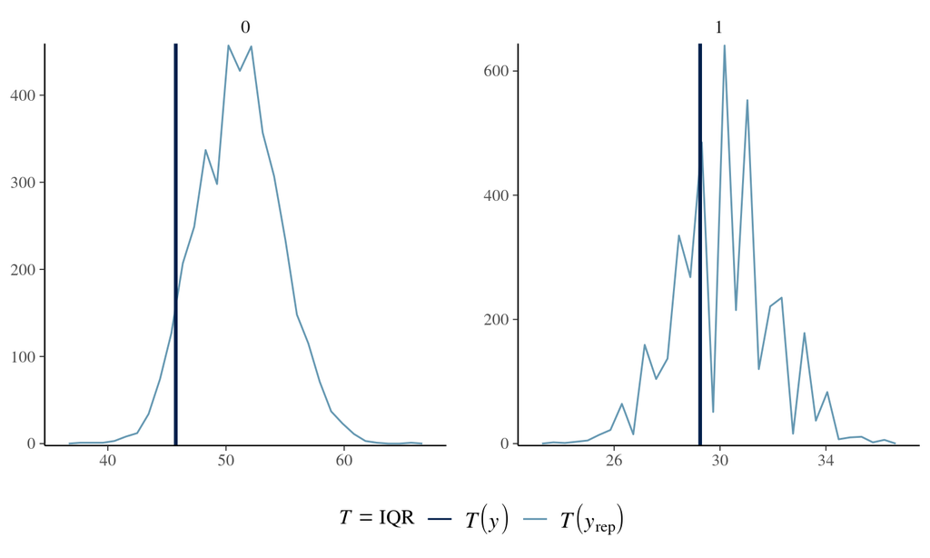

```r
pp_check(post, plotfun = "stat_freqpoly_grouped", group = roaches$treatment, stat = "IQR") +
  legend_move("bottom")
```

## Empirical CDF

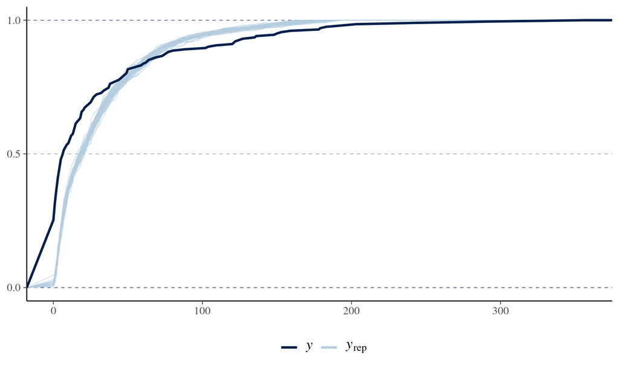

```r
pp_check(post, plotfun = "ecdf_overlay") + legend_move("bottom")
```

## MCMC Performance Plots

```r
format(available_mcmc(pattern = "data$", invert = TRUE))
```

```
##  [1] "mcmc_acf              " "mcmc_acf_bar          " "mcmc_areas            "
##  [4] "mcmc_areas_ridges     " "mcmc_combo            " "mcmc_dens             "
##  [7] "mcmc_dens_chains      " "mcmc_dens_overlay     " "mcmc_hex              "
## [10] "mcmc_hist             " "mcmc_hist_by_chain    " "mcmc_intervals        "
## [13] "mcmc_neff             " "mcmc_neff_hist        " "mcmc_nuts_acceptance  "
## [16] "mcmc_nuts_divergence  " "mcmc_nuts_energy      " "mcmc_nuts_stepsize    "
## [19] "mcmc_nuts_treedepth   " "mcmc_pairs            " "mcmc_parcoord         "
## [22] "mcmc_rank_hist        " "mcmc_rank_overlay     " "mcmc_recover_hist     "
## [25] "mcmc_recover_intervals" "mcmc_recover_scatter  " "mcmc_rhat             "
## [28] "mcmc_rhat_hist        " "mcmc_scatter          " "mcmc_trace            "
## [31] "mcmc_trace_highlight  " "mcmc_violin           "
```

## Autocorrelation Function

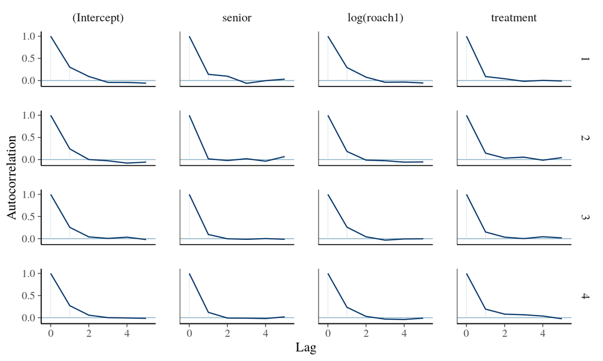

```r
mcmc_acf(post, lags = 5)
```

## Ridges

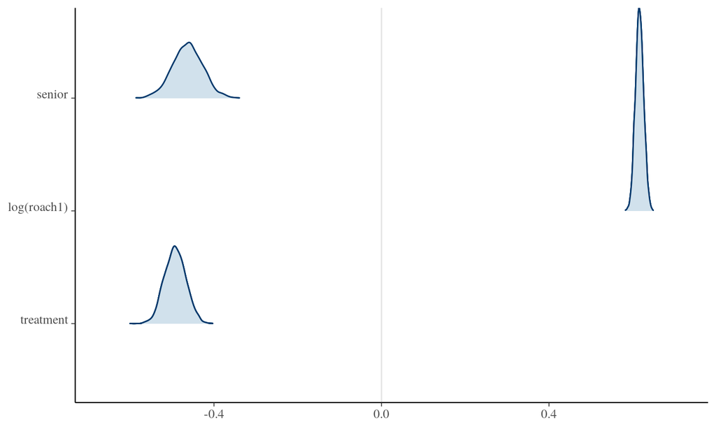

```r
mcmc_areas_ridges(post, regex_pars = "^[^(]") # exclude (Intercept)
```

## Hexograms

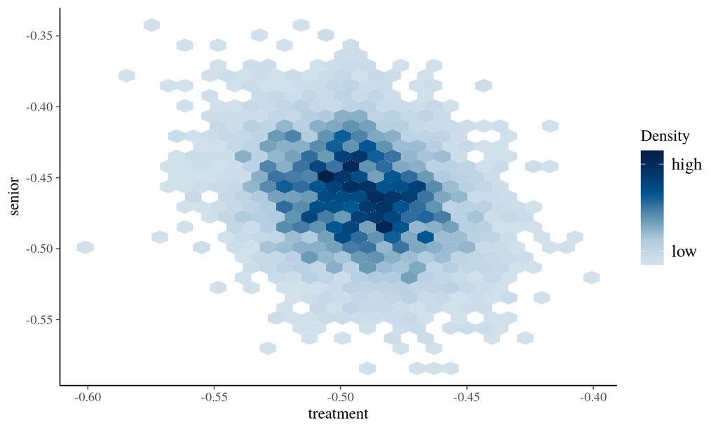

```r
mcmc_hex(post, pars = c("treatment", "senior"))
```

## Pairs

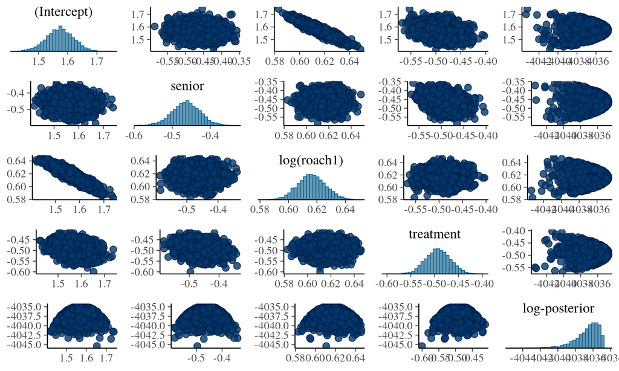

```r
pairs(post)
```

## Parallel Coordinates

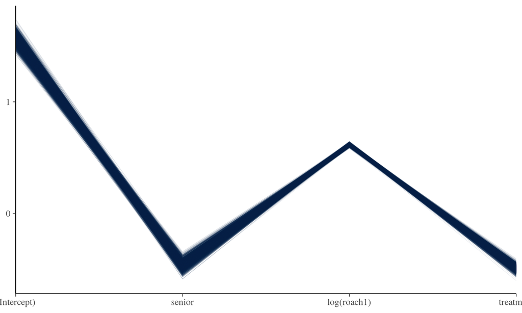

```r
mcmc_parcoord(post, alpha = 0.1, np = nuts_params(post),
              np_style = parcoord_style_np(div_color = "red", div_size = 1, div_alpha = 1))
```

## Prior Predictive Distribution for Well Switching

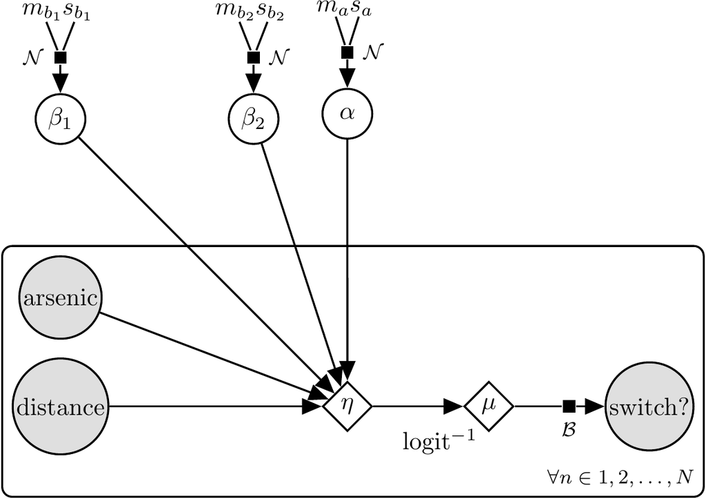

Well Switching Model

## Prior Predictive Distribution in Symbols

\[ \alpha \thicksim \mathcal{N}\left(m_\alpha, s_\alpha\right) \\ \beta_1 \thicksim \mathcal{N}\left(m_{\beta_1}, s_{\beta_1}\right) \\ \beta_2 \thicksim \mathcal{N}\left(m_{\beta_2}, s_{\beta_2}\right) \\ \forall n: \eta_n = \alpha + \beta_1 \times ARSENIC_n + \beta_2 \times DISTANCE_n \\ \forall n: \epsilon_n \thicksim \mathcal{Logistic}\left(0,1\right) \\ \forall n: u_n = \eta_n + \epsilon_n \\ \forall n: Y_n = u_n > 0 \]

## Inverse Link Functions

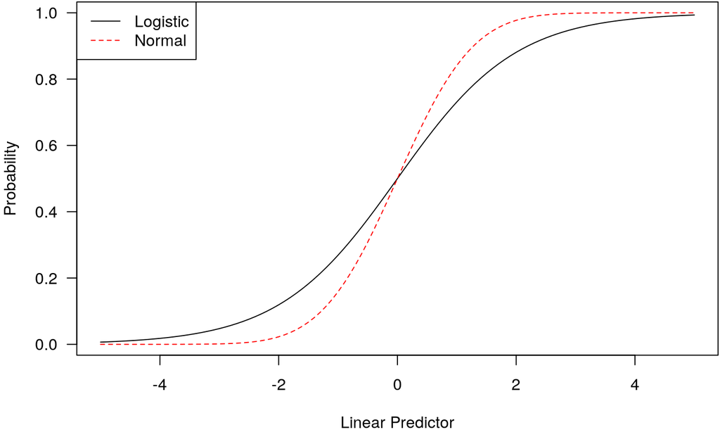

## Breakout Rooms

Draw \(S = 1000\) times (using `replicate`) from a prior predictive distribution

```r
str(wells)
```

```
## 'data.frame':    3020 obs. of  5 variables:
##  $ switch : int  1 1 0 1 1 1 1 1 1 1 ...
##  $ arsenic: num  2.36 0.71 2.07 1.15 1.1 3.9 2.97 3.24 3.28 2.52 ...
##  $ dist   : num  16.8 47.3 21 21.5 40.9 ...
##  $ assoc  : int  0 0 0 0 1 1 1 0 1 1 ...
##  $ educ   : int  0 0 10 12 14 9 4 10 0 0 ...
```

- You do not have to use `assoc` or `educ`
- To draw from the logistic distribution use `rlogis`
- Remember to center the predictors when predicting

## Posterior Distribution

```r
post <- stan_gamm4(switch ~ s(dist, arsenic), data = wells, family = binomial)
```

```r
print(post, digits = 2)
```

```
...
## (Intercept)         0.33   0.04
## s(dist,arsenic).1  -0.03   0.56
## s(dist,arsenic).2   0.00   0.55
## s(dist,arsenic).3   0.00   0.55
## s(dist,arsenic).4   0.00   0.53
## s(dist,arsenic).5  -0.06   0.53
## s(dist,arsenic).6  -0.02   0.52
## s(dist,arsenic).7   0.00   0.52
## s(dist,arsenic).8  -0.04   0.55
## s(dist,arsenic).9  -0.08   0.55
## s(dist,arsenic).10 -0.04   0.53
## s(dist,arsenic).11  0.05   0.57
## s(dist,arsenic).12  0.09   0.55
## s(dist,arsenic).13 -0.31   0.62
## s(dist,arsenic).14 -0.23   0.59
## s(dist,arsenic).15  0.04   0.55
## s(dist,arsenic).16  0.02   0.55
## s(dist,arsenic).17 -0.03   0.53
## s(dist,arsenic).18 -0.11   0.54
## s(dist,arsenic).19  0.08   0.53
## s(dist,arsenic).20  0.02   0.45
## s(dist,arsenic).21 -0.04   0.47
## s(dist,arsenic).22 -0.02   0.53
## s(dist,arsenic).23 -0.64   0.50
## s(dist,arsenic).24 -0.20   0.41
## s(dist,arsenic).25 -0.17   0.56
## s(dist,arsenic).26  0.08   0.54
## s(dist,arsenic).27 -0.02   0.42
## s(dist,arsenic).28  7.97   1.06
## s(dist,arsenic).29  6.80   2.11
##
## Smoothing terms:
##                             Median MAD_SD
## smooth_sd[s(dist,arsenic)1] 0.65   0.45
## smooth_sd[s(dist,arsenic)2] 4.62   1.19
##
## Sample avg. posterior predictive distribution of y:
##          Median MAD_SD
## mean_PPD 0.58   0.01
##
## ------
## * For help interpreting the printed output see ?print.stanreg
## * For info on the priors used see ?prior_summary.stanreg
...
```